# Enhancing Lattice Graphics

The following slides contain **new** commands that can be used to enhance the lattice graphics used in the IDS Course.

# Titles and axes

- The following **arguments** control the titles and axes for lattice plots.
- `main` Adds a title to your visual
- `sub` Adds a subtitle to your visual
- `xlab` Changes the label on the x-axis
- `ylab` Changes the label on the y-axis

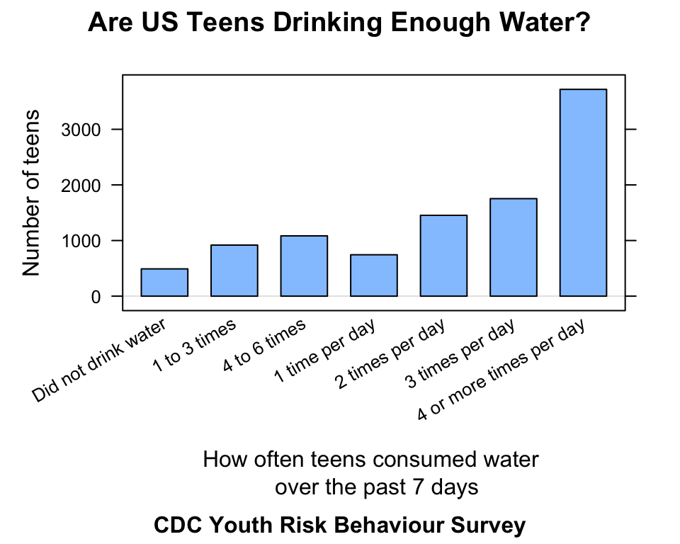

```r
bargraph(~drink_water, data=cdc,
         main = "Are US Teens Drinking Enough Water?",
         sub ="CDC Youth Risk Behaviour Survey",
         # use the newline character \n to make a new line of text
         xlab = "How often teens consumed water \n over the past 7 days",
         ylab = "Number of teens")
```

# Color & bargraphs

- `col` Changes the color of your visual
- To see the colors that are available, click **[here](https://r-charts.com/colors/)** or type the command `colors()` on your console, copy the output, and paste it in an RScript.

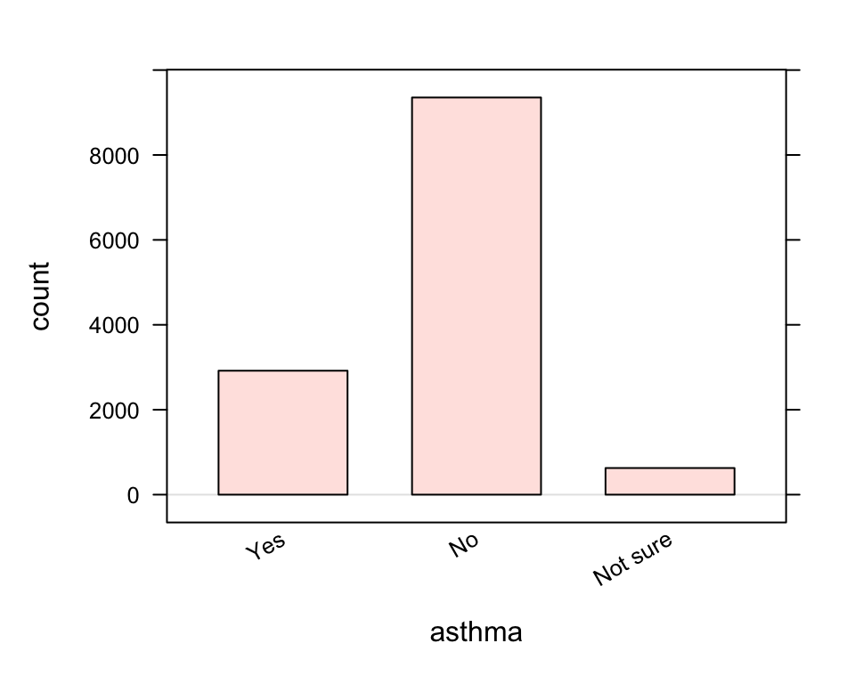

```r
bargraph(~asthma, data=cdc,
          col = "mistyrose")
```

- Sometimes we want to assign different colors to the bars in a bargraph. Utilizing the `groups` and `stack` arguments will allow us to do this. Let’s try this with the asthma variable. The asthma variable has three categories so we need to choose three colors for our plot.

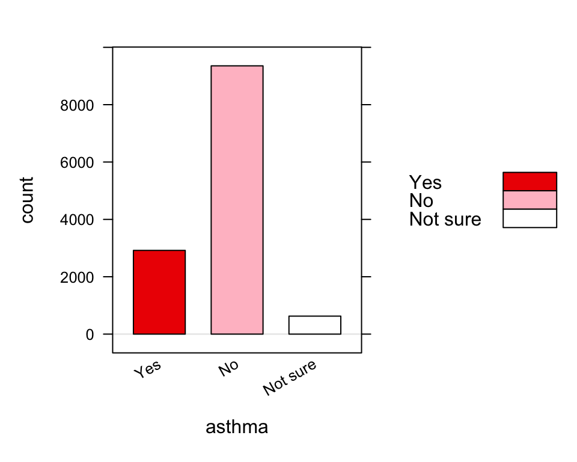

```r
bargraph(~asthma, data=cdc,
         groups = asthma,
         # assigned to the bars in the order they appear
         col=c("red2","pink","white"),
         stack = "TRUE")
```

# Color Palettes

On the previous slide you learned how to manually choose a color for each category of asthma. But what if there were a lot of categories for your variable? This is where a color palette might come in handy.

Type the following command in the console to load the ColorBrewer Palettes:

```r
library(RColorBrewer)
```

To view the palettes, type the following command:

```r
display.brewer.all()
```

The code below shows how to incorporate a palette with the `drink_water` variable:

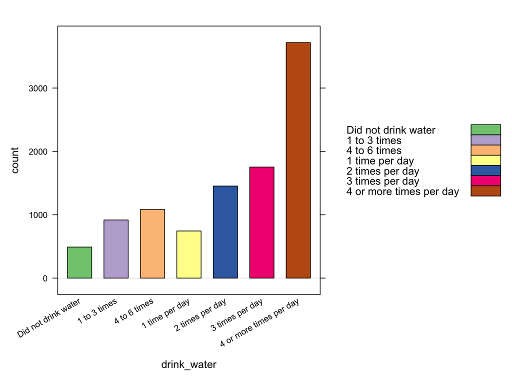

```r
#the first argument selects the number of colors
#in the order they appear on the palette
#the second argument is the palette name
palette <- brewer.pal(7, "Accent")

bargraph(~drink_water, data=cdc, groups = drink_water,
         col = palette,
         stack=T)
```

# Colored lines

- Create a histogram of `height` from the `cdc` data. Add vertical lines representing the mean and median of the data.
- Can you discern between mean and median?
- The `col` argument can be used in the `add_line` function to control the color of lines.
- Copy and paste the code below to color the mean line black and the median line red.

```r
add_line(vline = mean(~height,data=cdc), col="black")
add_line(vline = median(~height,data=cdc), col="red")
```

# Legends

- Although you might know the meaning of the chosen colors, your audience does not. The `key` argument is used to create a legend.

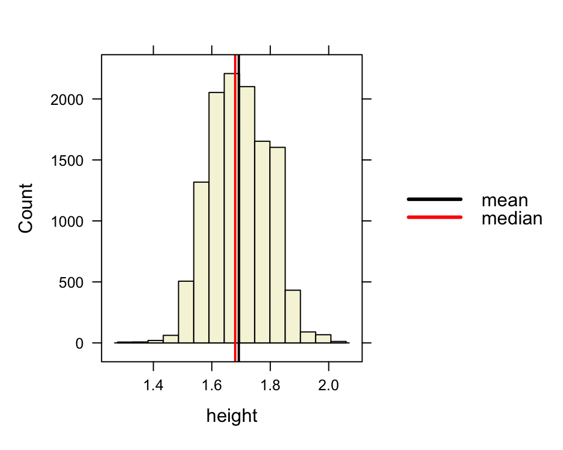

```r
histogram(~height, data=cdc,
          col = "beige",
          # space argument determines where your key is placed - "right", "left", "top", "bottom"
          key=list(space="right",
                   # color coding the lines and managing width in the key
                   lines=list(col=c("black","red"), lwd=3),
                   # labels for the lines in the key
                   text=list(c("mean","median"))))
add_line(vline = mean(~height,data=cdc), col="black")
add_line(vline = median(~height,data=cdc), col="red")
```

# More on Legends

- When you use the `groups` argument on a scatterplot, the key is automatically generated identifying the different categories. However, if you change the color of categories, the key does not automatically update.

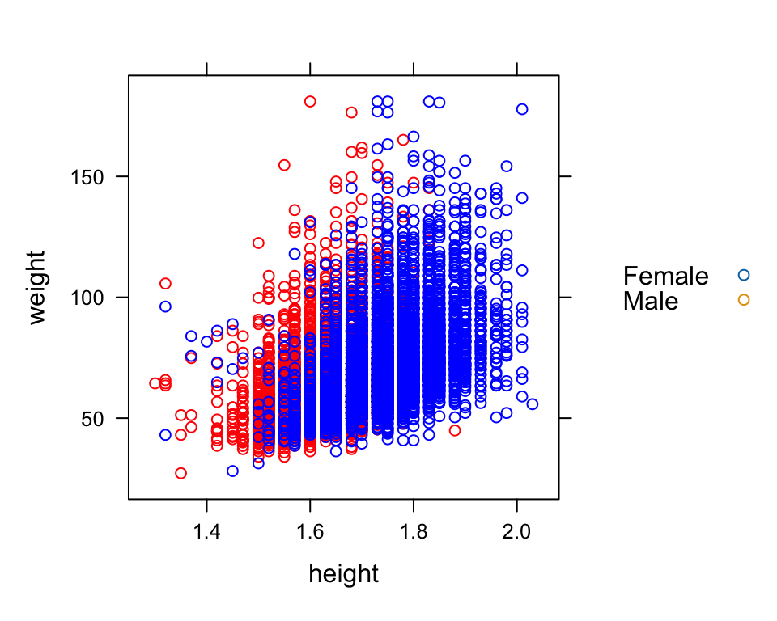

```r
xyplot(weight~height,data=cdc, groups=gender, col=c("red","blue"))
```

- To remedy this issue, you need to create your own key. You will be utilizing the `key` argument just like you did in the last slide.

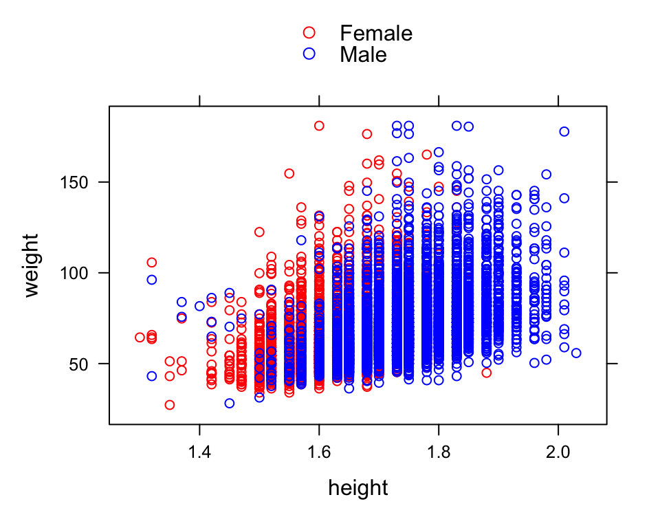

```r
xyplot(weight ~ height, data = cdc, groups = gender,
       col = c("red", "blue"),
       #The code below is for the key
       key = list(space = "top",
                  points = list(col = c("red", "blue"),
                                #shapes of points
                                pch = 1),
              #Make sure colors match with the variable categories
                  text = list(c("Female","Male")))
)
```

# Histograms and scales

- When creating a histogram, it can be frustrating trying to estimate the values on the x-axis. A solution is including the `scales` argument.

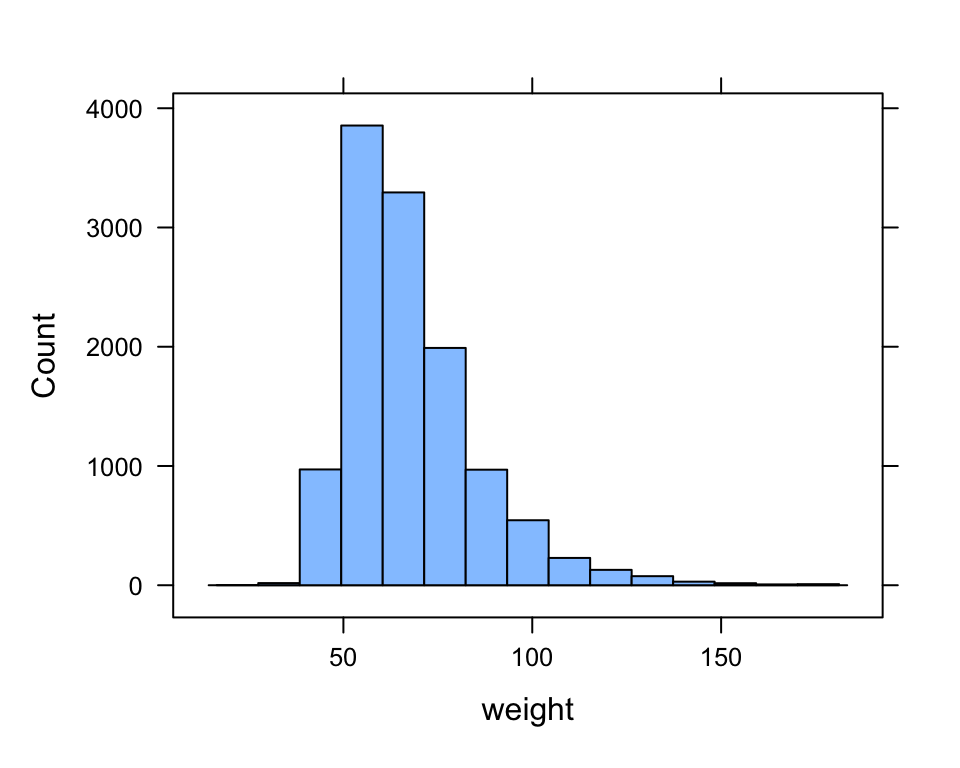

```r
histogram(~weight, data=cdc)
```

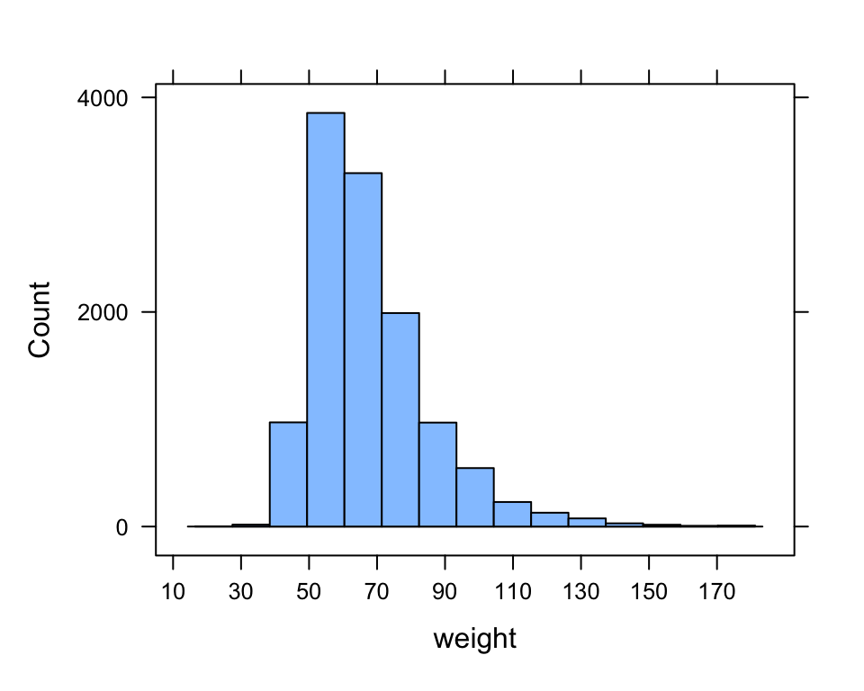

```r
histogram(~weight, data=cdc,
          # seq(from, to, by) tick marks beginning at 10 kg up to 180 kg by 20s
         scales=list(x=list(at=seq(10,180,20)),
                     # you can also choose specific values
                     y=list(at=c(0, 2000, 4000))
                     )
         )
```

# Histograms and breaks

- While the scales argument helped tremendously we can make the axes more readable by including the `breaks` argument along with the `scales` argument.
- We need to check the min and max values of the variable we are going to plot when using the `breaks` argument because they need to be included within the range of values.

```r
range(~weight, data=cdc)
```

```
## [1]  27.22 180.99
```

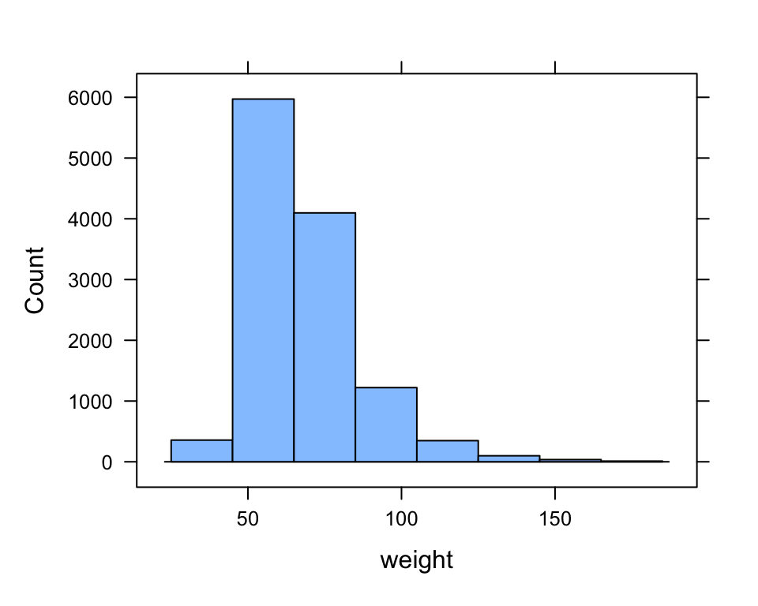

```r
histogram(~weight, data=cdc,
          # notice that 27.22 kg and 180.99 kg are included in the interval (25,185)
          breaks = seq(25,185,20))
```

- Including the scales argument to include labels at each break makes the plot more readable.

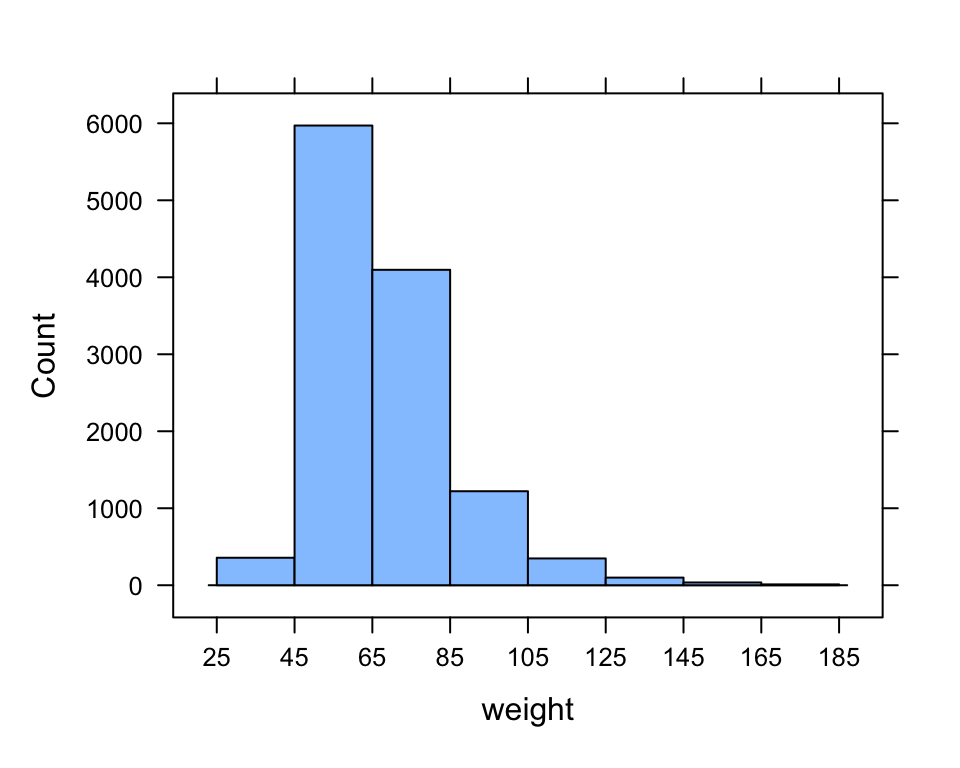

```r
histogram(~weight, data=cdc,
          breaks = seq(25,185,20),
          scales=list(x=list(at=seq(25,185,20))))
```

# Zooming in on the axis

- Distributions that are skewed or that contain outliers, can also impact the readability of a plot. The `xlim` argument allows you to control the lower and upper limits of the x-axis.

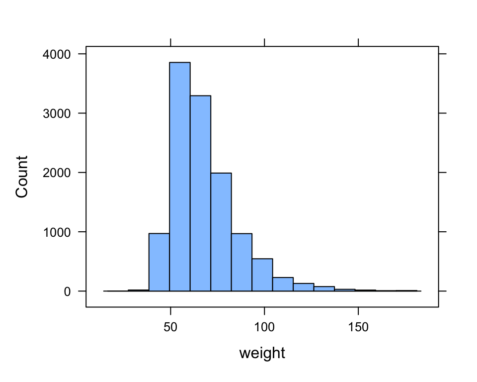

```r
histogram (~weight, data=cdc)
```

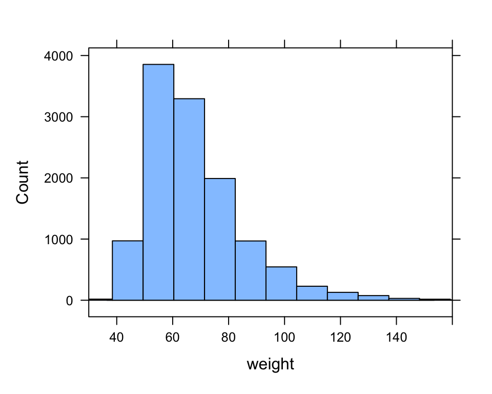

```r
histogram (~weight, data=cdc, xlim=c(30,160))
```

- There is also a `ylim` argument.

# Dotplots

- Dotplots are more appropriate for small data sets. Since most of our pre-loaded data sets are very large, we are going to create a vector with toy data. Copy and paste the code below in your console or an RScript.

```r
# will appear in your Environment Pane as Values
x <- c(5,5,6,7,8,8,8,9,10,10)
```

- Now that we have a vector of numerical values, we can make a dotplot. Since the values are not a variable in a data frame, you do not need the tilde (~) in your command.

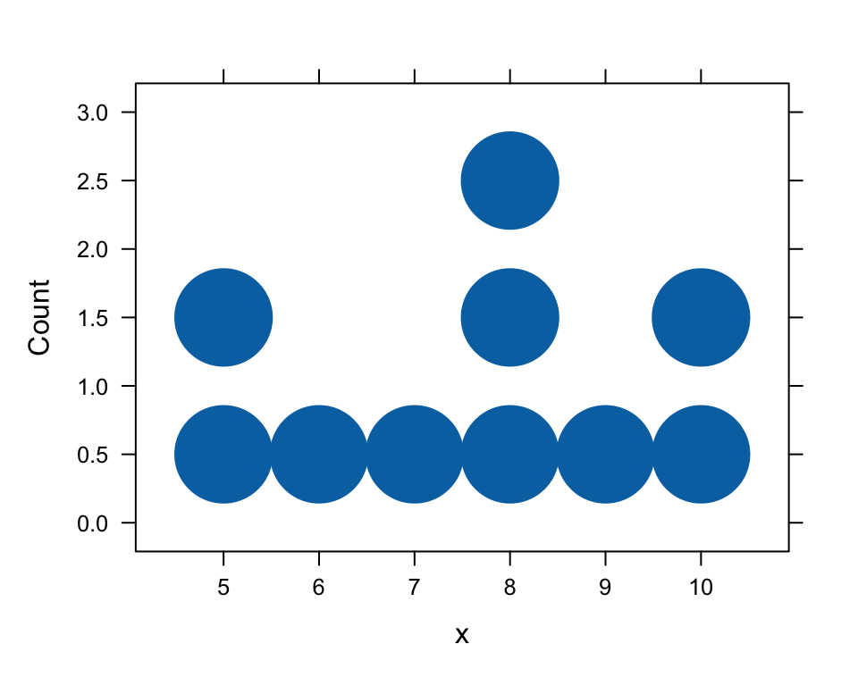

```r
# the nint was max minus min plus one (10 - 5 + 1)
dotPlot(x, nint = 6)
```

- The default plot character for a dotPlot is a dot but you can change that using the `pch` argument. Recall that you can also change the size of the characters with the `cex` argument.

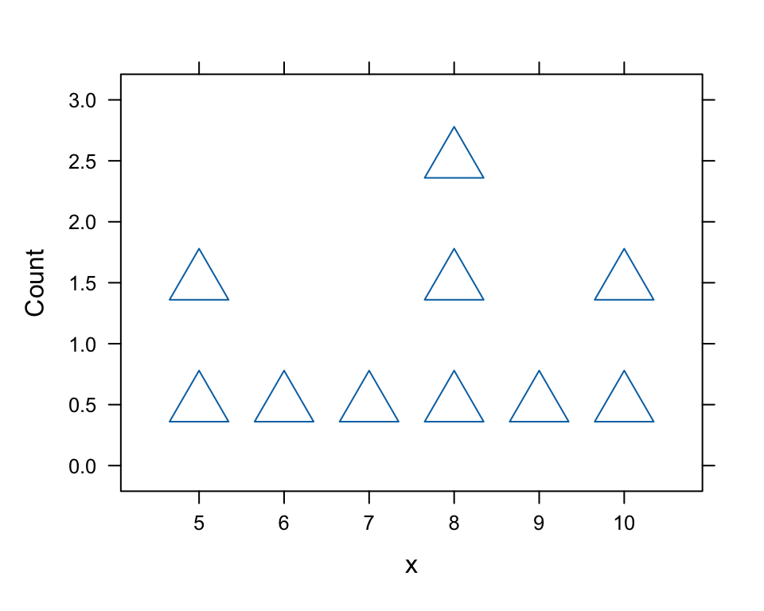

| pch value | shape |
| --- | --- |
| 0 | square |
| 1 | circle |
| 2 | triangle |
| 3 | plus |
| 4 | cross |
| 5 | diamond |
| 6 | triangle point down |
| 7 | square cross |

```r
dotPlot(x, nint = 6, pch = 2, cex = 0.5)
```

# Comparing plots

- Did you ever want to view the distribution of all of the color scores at the same time?
- If you do not have the colors data loaded on your *Environment*, do not worry, run the following code on your console:

```r
extra_data('colors_ids')
```

- Now that you have the data, follow the steps below:
- Step 1: Store all of the plots you want to include

```r
# these should appear in your Environment pane as a List
plot1<-bwplot(~blue, data = colors_ids, col ="blue")
plot2<-bwplot(~gold, data = colors_ids, col ="gold")
plot3<-bwplot(~green, data = colors_ids, col ="green", xlim=c(4, 21))
plot4<-bwplot(~orange, data = colors_ids, col ="orange")
```

- Step 2: Use the `grid.arrange` from the gridExtra Package

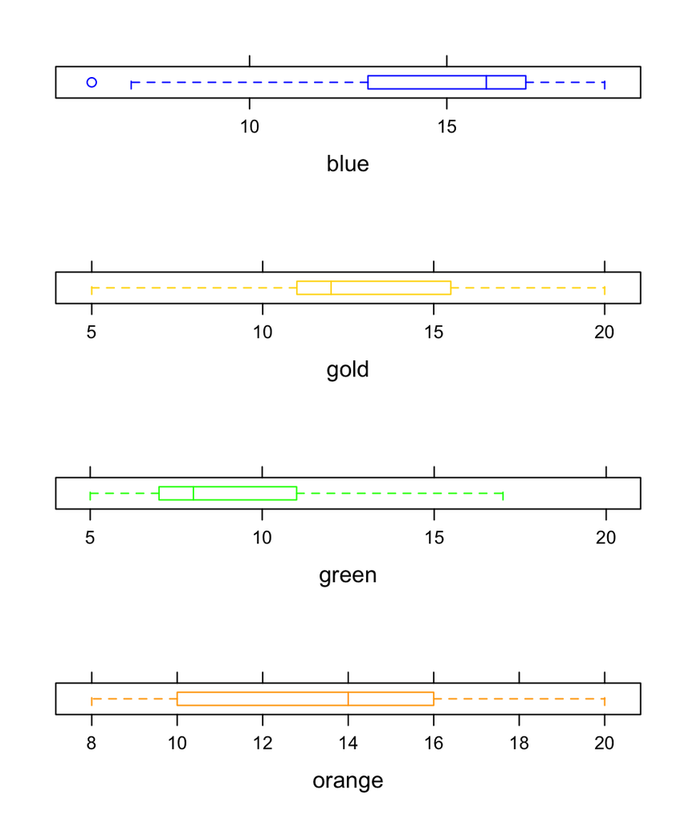

```r
gridExtra::grid.arrange(plot1, plot2, plot3, plot4, nrow = 4)
```

Note: You might need to click on the zoom button to see all 4 boxplots.

# On Your Own

Create a plot of your choice and include new arguments from this lab to spruce it up.